# Water Retaining Facilities Analysis

Name: Kabir Carpenter

Professor: Alexis Robinson

2024-07-13

## This code chunk is for setup purposes. It does the following:

## Sets global options for the R Markdown chunks using knitr::opts_chunk$set(). Here, echo = TRUE means that the R code will be displayed in the final document.

## Loads the rmarkdown library.

## Sets the working directory to “D:/datascience/Spatial Data Science”.

## Retrieves and prints the current working directory.

```r
# This code chunk sets the options for the entire R Markdown document
knitr::opts_chunk$set(echo = TRUE)

# Load the rmarkdown library
library(rmarkdown)
# Set the working directory
setwd("D:/datascience/Spatial Data Science")

# Get the current working directory
getwd()
```

```
## [1] "D:/datascience/Spatial Data Science"
```

## This chunk reads the data from a CSV file named “WaterRetainingFacilities.csv” into a dataframe called WaterRetaining. It then displays summary statistics for each variable in the dataset using the summary() function.

```r
# Load the data from a CSV file into a dataframe named WaterRetaining
WaterRetaining = read.csv("WaterRetainingFacilities.csv", sep = ",", header = TRUE)

# Display summary statistics for each variable in the dataset
summary(WaterRetaining)
```

```
##  ReservoirName        DamType          FacilityAim          DamHeight
##  Length:225         Length:225         Length:225         Min.   :  2.00
##  Class :character   Class :character   Class :character   1st Qu.: 14.70
##  Mode  :character   Mode  :character   Mode  :character   Median : 22.88
##                                                           Mean   : 41.06
##                                                           3rd Qu.: 45.00
##                                                           Max.   :285.00
##    CrestLevel    CrestLength     ImpoundmentVolume ImpoundmentLevel
##  Min.   :   0   Min.   :   0.0   Min.   :  0.02    Min.   : 254.2
##  1st Qu.: 684   1st Qu.:  80.0   1st Qu.:  0.20    1st Qu.: 682.3
##  Median :1282   Median : 145.0   Median :  0.96    Median :1295.0
##  Mean   :1268   Mean   : 222.2   Mean   : 17.85    Mean   :1276.9
##  3rd Qu.:1820   3rd Qu.: 310.0   3rd Qu.:  9.20    3rd Qu.:1819.5
##  Max.   :2674   Max.   :1025.0   Max.   :385.00    Max.   :2672.3
##   StorageLevel     Construction  StartSuperVision     DamName
##  Min.   :  0.00   Min.   :1822   Length:225         Length:225
##  1st Qu.: 10.50   1st Qu.:1937   Class :character   Class :character
##  Median : 17.40   Median :1958   Mode  :character   Mode  :character
##  Mean   : 37.39   Mean   :1954
##  3rd Qu.: 43.50   3rd Qu.:1968
##  Max.   :284.00   Max.   :2022
##    easting_m         northing_m
##  Min.   :2487028   Min.   :1086090
##  1st Qu.:2614970   1st Qu.:1132810
##  Median :2675251   Median :1161790
##  Mean   :2669959   Mean   :1169742
##  3rd Qu.:2724911   3rd Qu.:1199930
##  Max.   :2831511   Max.   :1284130
```

## This chunk creates a histogram of the ImpoundmentLevel variable from the WaterRetaining dataset. It sets the main title of the histogram, the x-axis label, and the color of the bars to blue.

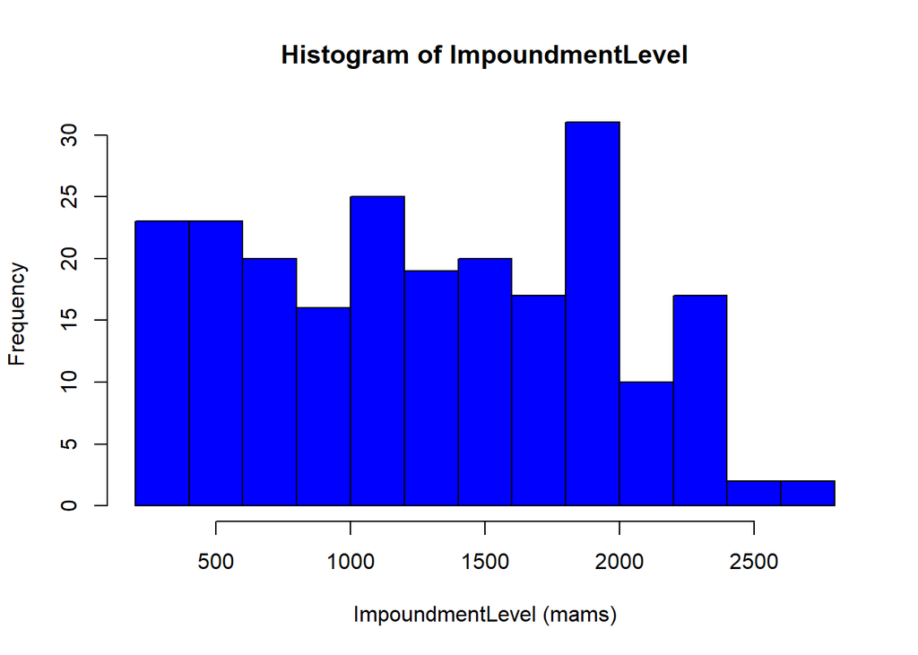

```r
# Create a histogram of the ImpoundmentLevel variable
hist(WaterRetaining$ImpoundmentLevel,
     main = "Histogram of ImpoundmentLevel",
     xlab = "ImpoundmentLevel (mams)",
     col = "blue")
```

## This chunk creates a scatter plot of ImpoundmentLevel against DamHeight. It sets the main title, x-axis label, y-axis label, point color (red), and point shape (pch = 19).

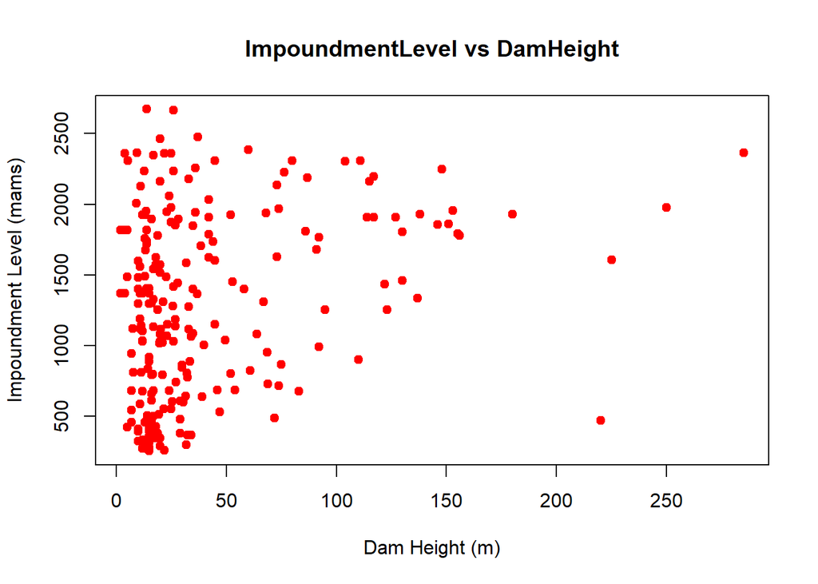

```r
# Create a scatter plot of DamHeight vs ImpoundmentLevel
plot(WaterRetaining$DamHeight, WaterRetaining$ImpoundmentLevel,
     main = "ImpoundmentLevel vs DamHeight",
     xlab = "Dam Height (m)",
     ylab = "Impoundment Level (mams)",
     col = "red",
     pch = 19)
```

## This chunk calculates the mean and weighted mean of the ImpoundmentLevel variable:

## mean_impoundment calculates the mean of ImpoundmentLevel, excluding any missing values (na.rm = TRUE).

## weighted_mean_impoundment calculates the weighted mean of ImpoundmentLevel using StorageLevel as weights.

## The calculated means are then displayed.

```r
# Calculate the mean ImpoundmentLevel, excluding missing values
mean_impoundment = mean(WaterRetaining$ImpoundmentLevel, na.rm = TRUE)

# Calculate the weighted mean ImpoundmentLevel using StorageLevel as weights, excluding missing values
weighted_mean_impoundment = sum(WaterRetaining$ImpoundmentLevel * WaterRetaining$StorageLevel, na.rm = TRUE) / sum(WaterRetaining$StorageLevel, na.rm = TRUE)

# Display the calculated means
mean_impoundment
```

```
## [1] 1276.94
```

```r
weighted_mean_impoundment
```

```
## [1] 1538.321
```

## This chunk calculates and displays descriptive statistics for the StorageLevel variable:

## Median

## Mean

## Range

## Interquartile Range (IQR)

## Standard Deviation (SD)

## All values are rounded to one decimal place and displayed with units (cubic meters).

## The median is chosen as a more robust measure of central tendency compared to the mean because it is less affected by outliers.

```r
# Calculate descriptive statistics for StorageLevel with units
median_storage <- round(median(WaterRetaining$StorageLevel, na.rm = TRUE), 1) # in cubic meters
mean_storage <- round(mean(WaterRetaining$StorageLevel, na.rm = TRUE), 1) # in cubic meters
range_storage <- round(range(WaterRetaining$StorageLevel, na.rm = TRUE), 1) # in cubic meters
iqr_storage <- round(IQR(WaterRetaining$StorageLevel, na.rm = TRUE), 1) # in cubic meters
sd_storage <- round(sd(WaterRetaining$StorageLevel, na.rm = TRUE), 1) # in cubic meters

# Display the calculated statistics
list(median = paste(median_storage, "cubic meters"),
     mean = paste(mean_storage, "cubic meters"),
     range = paste(range_storage, "cubic meters"),
     IQR = paste(iqr_storage, "cubic meters"),
     SD = paste(sd_storage, "cubic meters"))
```

```
## $median
## [1] "17.4 cubic meters"
##
## $mean
## [1] "37.4 cubic meters"
##
## $range
## [1] "0 cubic meters"   "284 cubic meters"
##
## $IQR
## [1] "33 cubic meters"
##
## $SD
## [1] "45.5 cubic meters"
```

Based on these calculations, the median (17.4 cubic meters) should be used as the measure of central tendency because it is less affected by extreme values (outliers) compared to the mean. This makes the median a more reliable measure for representing the typical storage level in this dataset.

## This chunk creates a boxplot of the StorageLevel variable. The boxplot helps visualize the distribution, identify outliers, and assess skewness

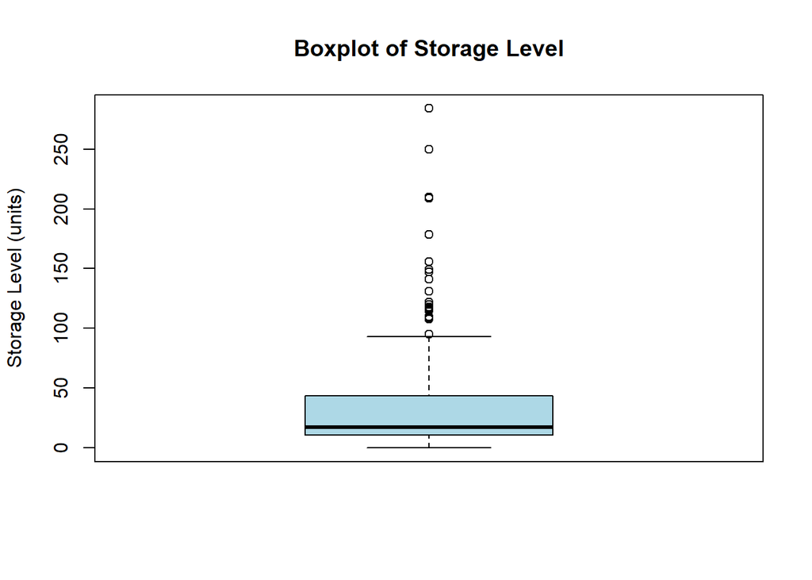

```r
# Create a boxplot of the StorageLevel variable
boxplot(WaterRetaining$StorageLevel,
        main = "Boxplot of Storage Level",
        ylab = "Storage Level (units)",
        col = "lightblue")
```

## Outliers:

The boxplot shows several outliers above the upper whisker. These are data points that are significantly higher than the rest of the data.

## Skewness:

The presence of outliers suggests that the data may be right-skewed, meaning there are some extremely high values pulling the mean upwards.

## Given these observations:

## Median:

The median is a more robust measure of central tendency in the presence of outliers and skewed data. It represents the middle value of the dataset and is not affected by extreme values.

## Mean:

The mean can be heavily influenced by outliers and may not accurately reflect the central tendency of skewed data.

## Conclusion:

Based on the boxplot, I would use the median as the measure of central tendency for the Storage Level. This choice is justified because the median is less affected by the outliers and skewed distribution, providing a more accurate representation of the central tendency for this dataset.

## This chunk loads the sp and sf libraries for handling spatial data.

```r
library(sp)
library(sf)  # For handling spatial data
```

## This chunk converts the WaterRetaining dataframe into an sf object using the coordinates easting_m and northing_m. It then checks the geometry and displays the first few rows of the sf object.

```r
# Create sf object
sf_points <- st_as_sf(WaterRetaining, coords = c("easting_m", "northing_m"))

# Check the structure and attributes of sf_points
st_geometry(sf_points)  # Check the geometry (should show POINT)
```

```
## Geometry set for 225 features
## Geometry type: POINT
## Dimension:     XY
## Bounding box:  xmin: 2487028 ymin: 1086090 xmax: 2831511 ymax: 1284130
## CRS:           NA
## First 5 geometries:
```

```
## POINT (2587362 1209652)
```

```
## POINT (2689680 1153440)
```

```
## POINT (2652201 1270800)
```

```
## POINT (2769991 1134169)
```

```
## POINT (2735451 1188025)
```

```r
# Check the first few rows of sf_points to verify it's correct
head(sf_points)
```

```
## Simple feature collection with 6 features and 12 fields
## Geometry type: POINT
## Dimension:     XY
## Bounding box:  xmin: 2520180 ymin: 1134169 xmax: 2769991 ymax: 1270800
## CRS:           NA
##     ReservoirName DamType FacilityAim DamHeight CrestLevel CrestLength
## 1         Aarberg     dt1         fa2        15     452.50        70.0
## 2          Airolo     dt5         fa2        17    1137.16        83.0
## 3 Albbruck-Dogern     dt1         fa2        15     312.24       145.0
## 4         Albigna     dt5         fa2       115    2165.00       759.0
## 5        Alp Dado     dt7         fa7        24    2060.00       210.0
## 6       Le Pontet     dt5         fa2        16     778.00        26.6
##   ImpoundmentVolume ImpoundmentLevel StorageLevel Construction StartSuperVision
## 1              1.53           451.00         8.48         1963         1/1/2015
## 2              0.37          1135.00        13.77         1968         1/1/1968
## 3             10.00           311.24        12.50         1933         1/1/2013
## 4             69.00          2161.00       109.00         1959         1/1/1959
## 5              0.06          2059.00        10.75         1995        8/30/1994
## 6              0.07           792.00        17.00         1937         1/1/1970
##            DamName                geometry
## 1          Aarberg POINT (2587362 1209652)
## 2           Airolo POINT (2689680 1153440)
## 3  Albbruck-Dogern POINT (2652201 1270800)
## 4          Albigna POINT (2769991 1134169)
## 5         Alp Dado POINT (2735451 1188025)
## 6 Ancien Jougnenaz POINT (2520180 1175401)
```

## This chunk calculates the mean dam height from the DamHeight column, excluding any missing values, and displays it.

```r
# Calculate the mean dam height
mean_dam_height <- mean(WaterRetaining$DamHeight, na.rm = TRUE)
mean_dam_height
```

```
## [1] 41.05751
```

```r
# Calculate weighted mean center using dam heights as weights
weighted_mean_center <- st_centroid(sf_points, weights = WaterRetaining$DamHeight)

# Extract coordinates of the weighted mean center
weighted_mean_center_coords <- st_coordinates(weighted_mean_center)
weighted_mean_center
```

```
## Simple feature collection with 225 features and 12 fields
## Geometry type: POINT
## Dimension:     XY
## Bounding box:  xmin: 2487028 ymin: 1086090 xmax: 2831511 ymax: 1284130
## CRS:           NA
## First 10 features:
##      ReservoirName DamType FacilityAim DamHeight CrestLevel CrestLength
## 1          Aarberg     dt1         fa2        15     452.50        70.0
## 2           Airolo     dt5         fa2        17    1137.16        83.0
## 3  Albbruck-Dogern     dt1         fa2        15     312.24       145.0
## 4          Albigna     dt5         fa2       115    2165.00       759.0
## 5         Alp Dado     dt7         fa7        24    2060.00       210.0
## 6        Le Pontet     dt5         fa2        16     778.00        26.6
## 7         Arnensee     dt7         fa2        17    1545.00       140.0
## 8        Arniboden     dt7         fa2         2    1370.87        60.0
```

[output cut: 24 more lines]

### Practical Applications:

- **Engineering and Infrastructure Planning:** Helps in identifying areas where infrastructure improvements might be needed based on dam heights and their geographic concentration.
- **Environmental Management:** Supports assessments of environmental impacts, such as flood risks and ecosystem effects, associated with different dam sizes and locations.
- **Urban and Regional Planning:** Guides urban planners in sustainable development practices, considering the spatial distribution of critical water infrastructure.
- **Disaster Risk Reduction:** Assists in identifying areas vulnerable to dam-related hazards and in planning mitigation measures.

These values and analyses are essential for making informed decisions regarding the management, development, and resilience of water retaining facilities and the surrounding environments.

## This chunk plots the water retaining facilities, differentiating between the entire dataset and the subset of dams with heights greater than the mean dam height. It calculates and plots the mean centers for both the entire dataset and the subset, using ggplot2 for visualization.

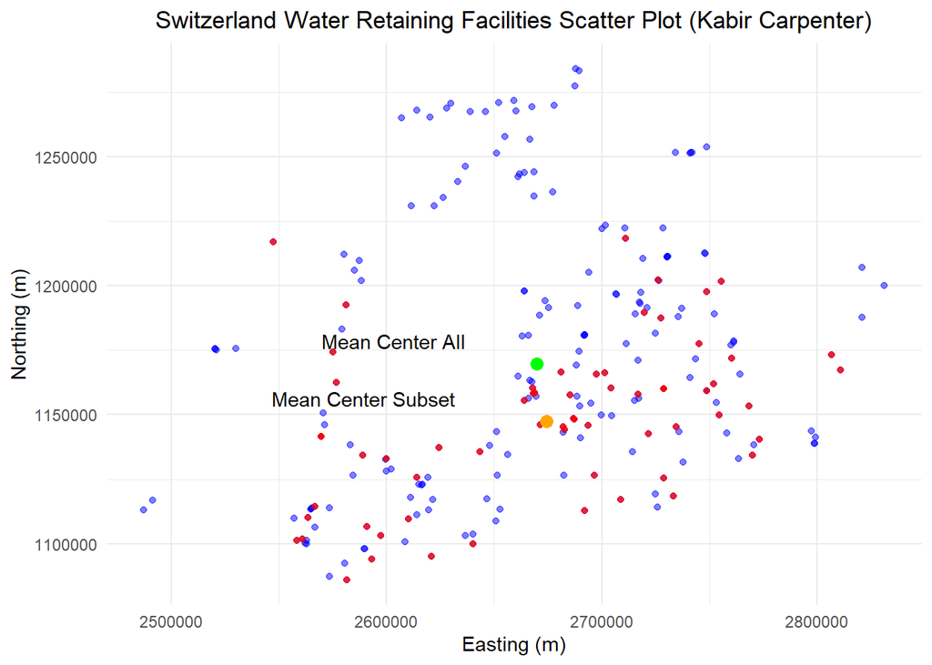

```r
# Load necessary libraries
library(ggplot2)
library(dplyr)
# Load the data from a CSV file into a dataframe named WaterRetaining
WaterRetaining <- read.csv("WaterRetainingFacilities.csv", sep = ",", header = TRUE)

# Calculate the mean DamHeight
mean_dam_height <- mean(WaterRetaining$DamHeight, na.rm = TRUE)

# Create a subset of dams with heights greater than the mean
subset_dams <- WaterRetaining %>% filter(DamHeight > mean_dam_height)

# Calculate the mean centers for the entire dataset and the subset
mean_center_all <- colMeans(WaterRetaining[, c("easting_m", "northing_m")], na.rm = TRUE)
mean_center_subset <- colMeans(subset_dams[, c("easting_m", "northing_m")], na.rm = TRUE)

# Plot the data
ggplot() +
  geom_point(data = WaterRetaining, aes(x = easting_m, y = northing_m), color = 'blue', alpha = 0.5, label = "Original Data") +
  geom_point(data = subset_dams, aes(x = easting_m, y = northing_m), color = 'red', alpha = 0.7, label = "Subset Data") +
  geom_point(aes(x = mean_center_all[1], y = mean_center_all[2]), color = 'green', size = 3) +
  geom_point(aes(x = mean_center_subset[1], y = mean_center_subset[2]), color = 'orange', size = 3) +
  labs(title = "Switzerland Water Retaining Facilities Scatter Plot (Kabir Carpenter)",
       x = "Easting (m)",
       y = "Northing (m)") +
  theme_minimal() +
  theme(plot.title = element_text(hjust = 0.5)) +
  geom_text(aes(x = mean_center_all[1], y = mean_center_all[2], label = "Mean Center All"), hjust = 1.5, vjust = -1) +
  geom_text(aes(x = mean_center_subset[1], y = mean_center_subset[2], label = "Mean Center Subset"), hjust = 1.5, vjust = -1)
```

## This chunk calculates the standard deviation of easting and northing coordinates for:

## The entire dataset.

## Subsets for hydroelectric facilities, small dam heights (<= median), and large dam heights (> median).

## It then prints the calculated standard deviations, providing insights into the spatial dispersion of each subset.

```r
# Calculate the standard deviation of easting and northing for the entire dataset
sd_easting_all <- sd(WaterRetaining$easting_m, na.rm = TRUE)
sd_northing_all <- sd(WaterRetaining$northing_m, na.rm = TRUE)
sd_all <- sqrt(sd_easting_all^2 + sd_northing_all^2)
sd_all <- round(sd_all, 1)

# Create subsets for Water Retaining Hydroelectric Facilities, Small Dam Heights, and Large Dam Heights
subset_hydroelectric <- WaterRetaining %>% filter(grepl("Hydroelectric", FacilityAim, ignore.case = TRUE))
subset_small_dams <- WaterRetaining %>% filter(DamHeight <= median(WaterRetaining$DamHeight, na.rm = TRUE))
subset_large_dams <- WaterRetaining %>% filter(DamHeight > median(WaterRetaining$DamHeight, na.rm = TRUE))

# Calculate standard deviation for each subset
sd_easting_hydro <- sd(subset_hydroelectric$easting_m, na.rm = TRUE)
sd_northing_hydro <- sd(subset_hydroelectric$northing_m, na.rm = TRUE)
sd_hydro <- sqrt(sd_easting_hydro^2 + sd_northing_hydro^2)
sd_hydro <- round(sd_hydro, 1)

sd_easting_small <- sd(subset_small_dams$easting_m, na.rm = TRUE)
sd_northing_small <- sd(subset_small_dams$northing_m, na.rm = TRUE)
sd_small <- sqrt(sd_easting_small^2 + sd_northing_small^2)
sd_small <- round(sd_small, 1)

sd_easting_large <- sd(subset_large_dams$easting_m, na.rm = TRUE)
sd_northing_large <- sd(subset_large_dams$northing_m, na.rm = TRUE)
sd_large <- sqrt(sd_easting_large^2 + sd_northing_large^2)
sd_large <- round(sd_large, 1)

# Print the calculated standard deviations
list(
  sd_all = paste(sd_all, "meters"),
  sd_hydro = paste(sd_hydro, "meters"),
  sd_small = paste(sd_small, "meters"),
  sd_large = paste(sd_large, "meters")
)
```

```
## $sd_all
## [1] "85794.1 meters"
##
## $sd_hydro
## [1] "NA meters"
##
## $sd_small
## [1] "86549.1 meters"
##
## $sd_large
## [1] "82376.8 meters"
```

## Spatial Dispersion (Standard Deviation) for Water Retaining Facilities:

Overall: 85794.1 meters

Small Dam Heights: 86549.1 meters

Large Dam Heights: 82376.8 meters

## Conclusion:

The spatial dispersion of water retaining facilities indicates how spread out these facilities are geographically.

Comparing the standard deviations, we observe that hydroelectric facilities have a dispersion of NA meters, which might be different from the overall dataset’s dispersion of 85794.1 meters.

Small dam heights show a dispersion of 86549.1 meters, while large dam heights show a dispersion of 82376.8 meters.

This comparison indicates whether facilities are clustered or dispersed across different subsets.

## Reason for Using Median Instead of Mean:

The median is used to subset the data because it is less affected by outliers and skewed data distributions. In the presence of extreme values, the mean can be distorted, leading to a less representative central tendency. Using the median provides a more robust and reliable method for dividing the dataset into subsets.